# Antibiotics and mortality

# Examine real mortality data from AEJ-Applied paper

## View time-series

```r
# State-level data for regressions
state_mortality = as.data.table(haven::read_dta("data/raw/113743-V1/AEJApp-20080229_Datasets/20080229_state_data.dta"))

    # Make sure things we want to look at are in the same units
    state_mortality[, infl_pneumonia_rate := infl_pneumonia_rate*100000]
    state_mortality[, tb_rate := tb_rate*100000]

# National level data for image
national_mortality =  as.data.table(haven::read_dta("data/raw/113743-V1/AEJApp-20080229_Datasets/20080229_national_data.dta"))
```

Quick look at the data

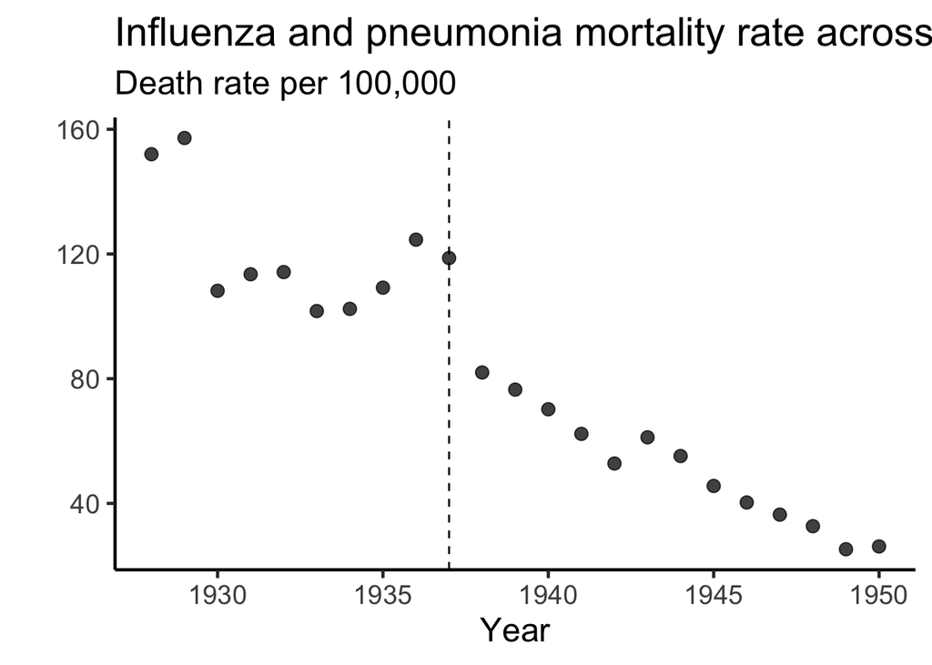

```r
flu_plot = ggplot(data = subset(national_mortality, year >= 1928),
                  aes(x = year, y = (influenza_pneumonia_total))) +
    geom_point(size = 3, alpha = .75) +
    theme_classic(base_size = 18) +
    geom_vline(xintercept = 1937, linetype="dashed") +
    labs(title = "Influenza and pneumonia mortality rate across time",
         y = "",
         subtitle = "Death rate per 100,000",
         x = "Year") +
    theme(legend.position = "none")

flu_plot
```

## Simple DiD

Compare changes in influenza death rates, before and after the invention of sulfa-drugs, to changes in tuberculosis death rates. Original AEJ paper discusses how TB was less affected.

### Time-series comparison

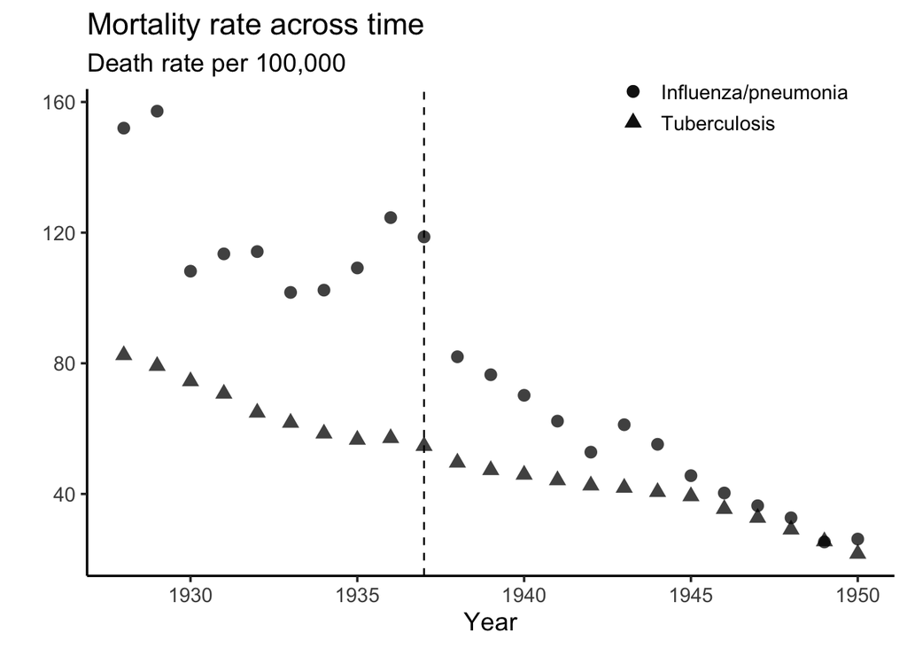

### DiD comparison

To make this comparison, I will first work with the state-level data. We will reshape the data, call treatment 1937 and after, create post $\times$ treat variable.

Run simple DiD

```r
simple_did = fixest::feols(value  ~ treated | treated_disease + state_pc + year,
              data = state_mortality_reshape)
```

```
NOTE: 96 observations removed because of NA values (LHS: 96).
```

```r
etable(simple_did)
```

```
                          simple_did
Dependent Var.:                value

treated         -25.00*** (7.78e-10)
Fixed-Effects:  --------------------
treated_disease                  Yes
state_pc                         Yes
year                             Yes
_______________ ____________________
S.E.: Clustered  by: treated_disease
Observations                   2,696
R2                           0.80640
Within R2                    0.09325
---
Signif. codes: 0 '***' 0.001 '**' 0.01 '*' 0.05 '.' 0.1 ' ' 1
```

```r
effect = simple_did$coeftable[1,1]
```

There is a -25 change in the influenza and pneumonia mortality rate per 100,000, relative to the change in tuberculosis mortality, following the advent of sulfa-drugs.

# Example using fake data

Add random variable to each state to get fake treated_year

First create percentiles

```r
quantiles = state_mortality[year == 1928, .(untreated = quantile(infl_pneumonia_rate, 0.25, na.rm = TRUE), low = quantile(infl_pneumonia_rate, 0.5, na.rm = TRUE), high = quantile(infl_pneumonia_rate, 0.75, na.rm = TRUE))]
```

Use these percentiles to create cutoffs in fake treatment.

- Lowest 25% is “never treated”
- 25-50% is late
- 50-75% is middle
- 75%+ is early

```r
state_mortality[year == 1928, fake_year_treated := ifelse(infl_pneumonia_rate <= quantiles$untreated, 2020, ifelse(infl_pneumonia_rate > quantiles$untreated & infl_pneumonia_rate <= quantiles$low, 1945,
                                     ifelse(infl_pneumonia_rate > quantiles$low & infl_pneumonia_rate <= quantiles$high, 1940, 1930)))]

state_mortality = state_mortality[, fake_year_treated := fake_year_treated[year == 1928], by = state_pc]
```

## Create data with staggered adoption, growing, and heterogenous treatment effect.

```r
# Keep only the variables that we need from 1928
timing_yes_growing_yes = state_mortality[year == 1928,.(state_pc, infl_pneumonia_rate, fake_year_treated, pop3)]

# Expand the dataset to be from 1928 until 1950
full_state_year_grid = data.table(expand.grid(year=1928:1950, state_pc =unique(timing_yes_growing_yes$state_pc)))

# Create error
error_mean = 0
error_sd = 10
error_scale = 1

full_state_year_grid[,rand_e:=1-rnorm(.N, 0, error_sd)]
full_state_year_grid[year == 1928, rand_st:=1-rnorm(.N, 0, error_sd)]
full_state_year_grid[state_pc == "AL", rand_yr:=1-rnorm(.N, 0, error_sd)]

full_state_year_grid = full_state_year_grid[, rand_st := rand_st[year == 1928], by = state_pc]
full_state_year_grid = full_state_year_grid[, rand_yr := rand_yr[state_pc == "AL"], by = year]

# Merge the two togethers
timing_yes_growing_yes = merge(timing_yes_growing_yes, full_state_year_grid, by = "state_pc")

# Add fake treatment status in each year
timing_yes_growing_yes[, treated := ifelse(year >= fake_year_treated, 1, 0)]

# Add "natural" slope from pre-trend
timing_yes_growing_yes[, fake_value := infl_pneumonia_rate - .1*rand_st + .05*rand_yr + .1*rand_e]

# Add treatment effect
timing_yes_growing_yes[, fake_value := ifelse(fake_year_treated == 1940, fake_value + 0*effect*treated + (.2*simple_did$coeftable[1,1]*(year - fake_year_treated)*treated), ifelse(fake_year_treated == 1945, fake_value + 0*effect*treated + (.1*simple_did$coeftable[1,1]*(year - fake_year_treated)*treated),fake_value + 0*effect*treated + (.3*simple_did$coeftable[1,1]*(year - fake_year_treated)*treated)))]

# Bound at zero
timing_yes_growing_yes[, fake_value := ifelse(fake_value < 0, 0, fake_value)]

# Calculate true treatment effect
timing_yes_growing_yes[, true_treatment_effect := fake_value - (infl_pneumonia_rate - .1*rand_st + .05*rand_yr + .1*rand_e)]

# Collapse into timing groups
timing_yes_growing_yes_collapsed = collap(timing_yes_growing_yes, ~ year + fake_year_treated, fmean, cols = 10, w = timing_yes_growing_yes$pop3)
```

Determine true treatment effect, ATT by group, and avg-ATT by treated year

```r
# Now figure out
    # the average treatment effect for each group
    # the average treatment effect on the treated.

yearly_true_treatment_effect = timing_yes_growing_yes[, list(avg_true_treatment_effect = fmean(true_treatment_effect),
                                             count = fnobs(true_treatment_effect)),
                                      by = c("fake_year_treated", "treated", "year")]
yearly_true_treatment_effect[treated == 1, event_time := year - fake_year_treated]
annual_avg_treatment_effect = yearly_true_treatment_effect[, list(avg_true_treatment_effect = fmean(avg_true_treatment_effect, w = count), weight_for_total = fsum(count)),
                                      by = c("event_time")]


group_true_treatment_effect = timing_yes_growing_yes[, list(mean = fmean(true_treatment_effect),
                                             count = fnobs(true_treatment_effect)),
                                      by = c("fake_year_treated", "treated")]

group_att = group_true_treatment_effect[treated == 1]
```

Plot data

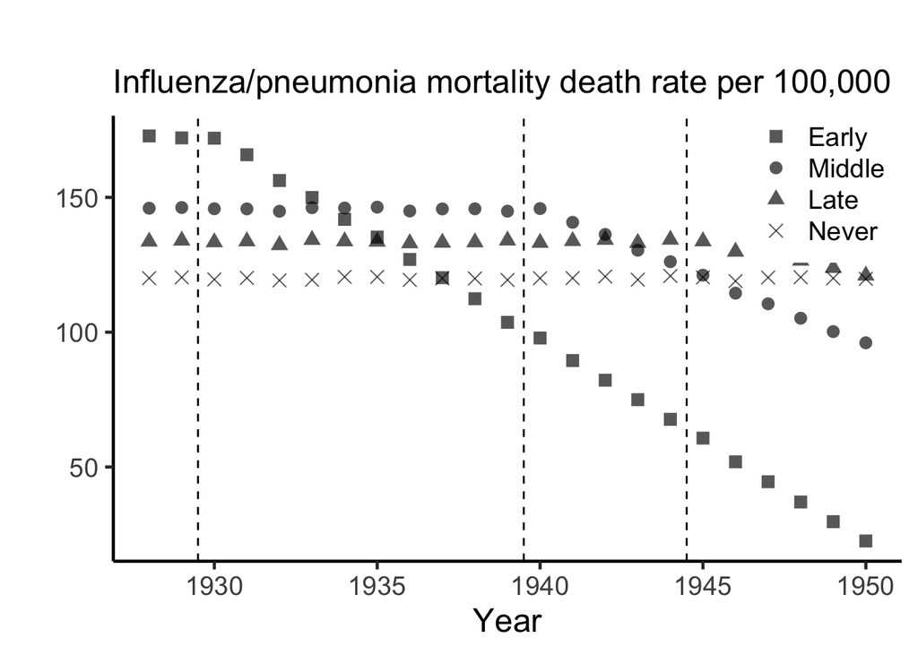

```r
timing_yes_growing_yes_plot = ggplot(data = timing_yes_growing_yes_collapsed,
                                    aes(x = year, y = (fake_value), shape = as.factor(fake_year_treated))) +
    geom_point(size = 3, alpha = .66) +
    theme_classic(base_size = 18) +
    geom_vline(xintercept = 1944.5, linetype="dashed") +
    geom_vline(xintercept = 1929.5, linetype="dashed") +
    geom_vline(xintercept = 1939.5, linetype="dashed") +
    labs(title = "",
         y = "",
         subtitle = "Influenza/pneumonia mortality death rate per 100,000",
         x = "Year") +
      scale_shape_manual(name = "",
                         values=c(15, 16, 17, 4),
                         labels = c("Early",
                                    "Middle",
                                    "Late",
                                    "Never"),
                         guide = 'legend') +
  theme(legend.position = c(.9, .9))
timing_yes_growing_yes_plot
```

# Treatment effect estimates by method

## Two-way fixed-effects

### ATT

```r
timing_yes_growing_yes_twfe = fixest::feols(fake_value ~ treated | state_pc + year, data = timing_yes_growing_yes)

# Estimate of the treatment effect is
timing_yes_growing_yes_twfe$coeftable[1,1]
```

```
[1] 5.059214
```

```r
timing_yes_growing_yes_twfe_att = data.table(order = 1,
                                        b = timing_yes_growing_yes_twfe$coeftable[1],
                                        se = timing_yes_growing_yes_twfe$coeftable[2],
                                        method = "TWFE")
```

### Event-study

```r
timing_yes_growing_yes_es_data = copy(timing_yes_growing_yes)
timing_yes_growing_yes_es_data[,fake_year_treated := ifelse(fake_year_treated == 2020, NA, fake_year_treated)]
timing_yes_growing_yes_es_data[,event_time := year - fake_year_treated]
timing_yes_growing_yes_es_data[,event_time_no_na := ifelse(is.na(event_time), -1, event_time)]
timing_yes_growing_yes_es_data[,ever_treated := ifelse(is.na(fake_year_treated), 0, 1)]


twfe_es = feols(fake_value ~ i(event_time_no_na, ever_treated, ref = -1) | state_pc + year,
                              data = timing_yes_growing_yes_es_data,
                           cluster = timing_yes_growing_yes_es_data$state_pc)

rm(timing_yes_growing_yes_es_data)

position_of_neg_1 = which(twfe_es$model_matrix_info[[1]]$items == -1)

    timing_yes_growing_yes_twfe_es = as.data.table(
            cbind(
                twfe_es$model_matrix_info[[1]]$items,
                append(twfe_es$coefficients, 0, position_of_neg_1-1),
                append(twfe_es$se, 0, position_of_neg_1-1),
                rep("TWFE",each=length(twfe_es$model_matrix_info[[1]]$items))
                )
            )

    colnames(timing_yes_growing_yes_twfe_es) = c("event_time", "b", "se", "type")
```

## Unbalanced-stacked

#### Functions for stacked balanced and stacked unbalanced.

```r
createBalancedStackedData = function(dataset, outcome, condition = NULL, timeTreated, timeID, groupID, k_pre, k_post, year_start_stack, year_end_stack, NotYetTreated = FALSE){

    dt_temp = copy(dataset)

    # If no restriction
    if (is.null(condition)) {
        print("Dataset returned without restriction")
    }

    # If restriction
    if (!is.null(condition)){
        # Convert condition from character to expression
        condition_expr = parse(text = condition)

        # Implement restriction
        dt_temp = dt_temp[eval(condition_expr)]

        print("Dataset returned with restriction")
    }

    # Remove rows that are NA for outcome
    outcome_fixed  = deparse(substitute(outcome))

    dt_temp = na.omit(dt_temp, cols = c(outcome_fixed))


    # Make a copy of the datasets so we don't cause issues
    dt_stack = copy(dt_temp)

    # Ensure it's a data.table object
    dt_stack = as.data.table(dt_stack)

    # Ever treated
    dt_stack[, temp_ever_treated := ifelse(!is.na(get(timeTreated)), 1, 0)]
    dt_stack[, event_time := get(timeID) - get(timeTreated)]

    # Step 1: Define an event window
    # This is done using k_pre, k_post, year_start_stack, and year_end_stack above
    # k_pre = -6
    # k_post = 6
    # year_start_stack = 1922
    # year_end_stack = 1942
    # get(groupID)

    # Step 2. Enumerate Sub-Experiments
    unique_sub_experiments = unique(dt_stack[!is.na(get(timeTreated)), .(get(timeTreated))])

    # For some reason the first column doesnt keep the name of the variable. Rename it
    setnames(unique_sub_experiments, "V1", eval(timeTreated))

    # Now for each sub-experiment, find the years we want to keep for the never-treated and not yet treated.
    sub_experiments_to_keep = unique_sub_experiments[get(timeTreated) >= year_start_stack - k_pre & get(timeTreated) <= year_end_stack - k_post]
    sub_experiments_to_keep[, max_year := get(timeTreated) + k_post]
    sub_experiments_to_keep[, min_year := get(timeTreated) + k_pre]

    # Step 3. Define Inclusion Criteria
    # Create a storage data.table
    temp_stack_storage = dt_stack
    temp_stack_storage[,stackID := 0]
    temp_stack_storage[,count := 0]
    temp_stack_storage[,treated_in_stack := 0]
    temp_stack_storage = temp_stack_storage[0,]

    for (i in 1:nrow(sub_experiments_to_keep)) {
        #i = 1
        stackYear = unlist(sub_experiments_to_keep[i,1])
        # First, find never treated control set within the window
        temp_dt_stack_nevertreat = dt_stack[temp_ever_treated == 0 & get(timeID) >= sub_experiments_to_keep$min_year[i] & get(timeID) <= sub_experiments_to_keep$max_year[i]]

        # Keep only groups present in each year
        temp_dt_stack_nevertreat[, count := .N, by = get(groupID)]
        temp_dt_stack_nevertreat = temp_dt_stack_nevertreat[count == k_post - k_pre + 1]

        # Add stack-id
        temp_dt_stack_nevertreat[,stackID := stackYear]
        temp_dt_stack_nevertreat[,treated_in_stack := 0]

        # Second, find the treated set for this sub-experiment. Being sure to remove years outside of the window
        # Keep ever_treated, and treated in this sub experiment
        sub_experiments_to_keep
        temp_dt_stack_treat = dt_stack[temp_ever_treated == 1 & get(timeTreated) == stackYear]

        # keep only years within window
        temp_dt_stack_treat = temp_dt_stack_treat[get(timeID) >= sub_experiments_to_keep$min_year[i] & get(timeID) <= sub_experiments_to_keep$max_year[i]]

        # Keep only groups present in each year
        temp_dt_stack_treat[, count := .N, by = get(groupID)]
        temp_dt_stack_treat = temp_dt_stack_treat[count == k_post - k_pre + 1]

        # Add stack-id
        temp_dt_stack_treat[,stackID := stackYear]
        temp_dt_stack_treat[,treated_in_stack := 1]

        # Step 4. Stack The Data
        temp_stack_storage = rbind(temp_stack_storage,
                                   temp_dt_stack_nevertreat,
                                   temp_dt_stack_treat)

        # Back to Step3, but for the not yet treated set for this sub-experiment.
        if (NotYetTreated == TRUE) {
            # Keep ever_treated, but not treated in this sub experiment
            temp_dt_stack_notyettreat = dt_stack[temp_ever_treated == 1 & get(timeTreated) != stackYear]
            # keep only years within window
            temp_dt_stack_notyettreat = temp_dt_stack_notyettreat[get(timeID) >= sub_experiments_to_keep$min_year[i] & get(timeID) <= sub_experiments_to_keep$max_year[i]]
            # Keep only those not yet treated observations that are outside of the window we are looking in
            temp_dt_stack_notyettreat = temp_dt_stack_notyettreat[event_time < k_pre]

            # Keep only groups present in each year
            temp_dt_stack_notyettreat[, count := .N, by = list(get(groupID))]
            temp_dt_stack_notyettreat = temp_dt_stack_notyettreat[count == k_post - k_pre + 1]

            # Add stack-id
            temp_dt_stack_notyettreat[,stackID := stackYear]
            temp_dt_stack_notyettreat[,treated_in_stack := 0]

            # Step 4. Stack The Data
            temp_stack_storage = rbind(temp_stack_storage,
                                       temp_dt_stack_notyettreat)
        }

    }
    # -----------------------------------------------------
    # Compute Weights
    # -----------------------------------------------------

    # Add an event time for all units
    temp_stack_storage[, all_event_time := get(timeID) - stackID]

    # Stack-time-level counts
    temp_stack_storage[, `:=` (stack_n = .N, stack_treat_n = sum(treated_in_stack),
                                   stack_control_n = sum(1 - treated_in_stack)),
                           by = all_event_time]

    # sub_exp-level counts
    temp_stack_storage[, `:=` (sub_n = .N, sub_treat_n = sum(treated_in_stack),
                                   sub_control_n = sum(1 - treated_in_stack)),
                           by = c("stackID", "all_event_time")]

    # sub-experiment shares of total by period
    temp_stack_storage[, sub_share := sub_n / stack_n]

    # Shares of treated and control groups within each sub experiment
    temp_stack_storage[, `:=` (sub_treat_share = sub_treat_n / stack_treat_n,
                                   sub_control_share = sub_control_n / stack_control_n)]


    # Compute weights
    temp_stack_storage[treated_in_stack == 1, cweight := 1]
    temp_stack_storage[treated_in_stack == 0, cweight := sub_treat_share/sub_control_share]

    # Remove temp_ever_treated and event_time to avoid any confusion later
    temp_stack_storage = temp_stack_storage[,-c("event_time", "temp_ever_treated")]

    return(temp_stack_storage)
}
```

```r
## Using unbalanced sample. Add this note to stacked. and CS figure.
createUnbalancedStackedData = function(dataset,  timeTreated, timeID, NotYetTreated = FALSE){
    #dataset = fake_mortality_data
    #timeTreated = time_treated

    dt_temp = copy(dataset)


    # Make a copy of the datasets so we don't cause issues
    dt_stack = copy(dt_temp)

    # Ensure it's a data.table object
    dt_stack = as.data.table(dt_stack)

    # Ever treated
    dt_stack[, temp_ever_treated := ifelse(!is.na(get(timeTreated)), 1, 0)]
    dt_stack[, event_time := get(timeID) - get(timeTreated)]

    # Step 1: Define an event window
    # This is done using k_pre, k_post, year_start_stack, and year_end_stack above
    # year_start_stack = 1922
    # year_end_stack = 1942
    # get(groupID)

    # Step 2. Enumerate Sub-Experiments
    unique_sub_experiments = unique(dt_stack[!is.na(get(timeTreated)), .(get(timeTreated))])

    # For some reason the first column doesnt keep the name of the variable. Rename it
    setnames(unique_sub_experiments, "V1", eval(timeTreated))

    # Now for each sub-experiment, find the years we want to keep for the never-treated and not yet treated.

    # Step 3. Define Inclusion Criteria
    # Create a storage data.table
    temp_stack_storage = dt_stack
    temp_stack_storage[,stackID := 0]
    temp_stack_storage[,count := 0]
    temp_stack_storage[,treated_in_stack := 0]
    temp_stack_storage = temp_stack_storage[0,]

    for (i in 1:nrow(unique_sub_experiments)) {
        # i = 1
        stackYear = unlist(unique_sub_experiments[i,1])
        # First, find never treated control set within the window
        temp_dt_stack_nevertreat = dt_stack[temp_ever_treated == 0]


        # Add stack-id
        temp_dt_stack_nevertreat[,stackID := stackYear]
        temp_dt_stack_nevertreat[,treated_in_stack := 0]

        # Second, find the treated set for this sub-experiment. Being sure to remove years outside of the window
        # Keep ever_treated, and treated in this sub experiment

        temp_dt_stack_treat = dt_stack[temp_ever_treated == 1 & get(timeTreated) == stackYear]

        # keep only years within window

        # Add stack-id
        temp_dt_stack_treat[,stackID := stackYear]
        temp_dt_stack_treat[,treated_in_stack := 1]

        # Step 4. Stack The Data
        temp_stack_storage = rbind(temp_stack_storage,
                                   temp_dt_stack_nevertreat,
                                   temp_dt_stack_treat)

        # Back to Step3, but for the not yet treated set for this sub-experiment.
        if (NotYetTreated == TRUE) {
            # Keep ever_treated, but not treated in this sub experiment
            temp_dt_stack_notyettreat = dt_stack[temp_ever_treated == 1 & get(timeTreated) > stackYear]
            # keep only years within window
            temp_dt_stack_notyettreat = temp_dt_stack_notyettreat[get(timeID) <= get(timeTreated)]
            # Keep only those not yet treated observations that are outside of the window we are looking in

            # Add stack-id
            temp_dt_stack_notyettreat[,stackID := stackYear]
            temp_dt_stack_notyettreat[,treated_in_stack := 0]

            # Step 4. Stack The Data
            temp_stack_storage = rbind(temp_stack_storage,
                                       temp_dt_stack_notyettreat)
        }

    }

    # -----------------------------------------------------
    # Compute Weights
    # -----------------------------------------------------

    # Add an event time for all units
    temp_stack_storage[, all_event_time := get(timeID) - stackID]

    # Stack-time-level counts
    temp_stack_storage[, `:=` (stack_n = .N, stack_treat_n = sum(treated_in_stack),
                               stack_control_n = sum(1 - treated_in_stack)),
                       by = all_event_time]

    # sub_exp-level counts
    temp_stack_storage[, `:=` (sub_n = .N, sub_treat_n = sum(treated_in_stack),
                               sub_control_n = sum(1 - treated_in_stack)),
                       by = c("stackID", "all_event_time")]

    # sub-experiment shares of total by period
    temp_stack_storage[, sub_share := sub_n / stack_n]

    # Shares of treated and control groups within each sub experiment
    temp_stack_storage[, `:=` (sub_treat_share = sub_treat_n / stack_treat_n,
                               sub_control_share = sub_control_n / stack_control_n)]


    # Compute weights
    temp_stack_storage[treated_in_stack == 1, cweight := 1]
    temp_stack_storage[treated_in_stack == 0, cweight := sub_treat_share/sub_control_share]

    # Remove temp_ever_treated and event_time to avoid any confusion later
    temp_stack_storage = temp_stack_storage[,-c("event_time", "temp_ever_treated")]

    return(temp_stack_storage)
}
```

```r
timing_yes_growing_yes_with_na = timing_yes_growing_yes[, fake_year_treated := ifelse(fake_year_treated == 2020, NA, fake_year_treated)]
```

```r
stacked_unbalanced = createUnbalancedStackedData(dataset = timing_yes_growing_yes_with_na,
                                      timeTreated = "fake_year_treated",
                                      timeID = "year",
                                      NotYetTreated = FALSE)
```

### ATT

```r
stacked_feols_unbalanced = feols(fake_value ~ treated | state_pc^stackID + year^stackID + state_pc + year + stackID,
                         data = stacked_unbalanced,
                           cluster = stacked_unbalanced$state_pc)

timing_yes_growing_yes_stacked_att = data.table(order = 3,
                                        b = stacked_feols_unbalanced$coeftable[1],
                                        se = stacked_feols_unbalanced$coeftable[2],
                                        method = "Unbalanced-Stacked")
```

### Event-study

```r
stacked_es_unbalanced = feols(fake_value ~ i(all_event_time, treated_in_stack, ref = -1) | state_pc^stackID + year^stackID,
                              data = stacked_unbalanced,
                           cluster = stacked_unbalanced$state_pc)

    timing_yes_growing_yes_stacked_es = as.data.table(
            cbind(
                stacked_es_unbalanced$model_matrix_info[[1]]$items,
                append(stacked_es_unbalanced$coefficients, 0, abs(min(stacked_es_unbalanced$model_matrix_info[[1]]$items))-1),
                append(stacked_es_unbalanced$se, 0, abs(min(stacked_es_unbalanced$model_matrix_info[[1]]$items))-1),
                rep("Stacked-Unbalanced",each=length(stacked_es_unbalanced$model_matrix_info[[1]]$items))
                )
            )

    colnames(timing_yes_growing_yes_stacked_es) = c("event_time", "b", "se", "type")
```

## Balanced-Stacked +/- 2: ATT

```r
 stacked_balanced_k_2 = createBalancedStackedData(dataset = timing_yes_growing_yes_with_na,
                                      outcome = fake_value,
                                      condition = NULL,
                                      timeTreated = "fake_year_treated",
                                      timeID = "year",
                                      groupID = "state_pc",
                                      k_pre = -2,
                                      k_post = 2,
                                      year_start_stack = 1928,
                                      year_end_stack = 1950,
                                      NotYetTreated = TRUE)
```

```
[1] "Dataset returned without restriction"
```

### Averge post-treatment effect

```r
stacked_balanced_k_2[,post_collapse_event_time := ifelse(all_event_time >= 0 , 1, all_event_time)]
stacked_balanced_k_2_res = feols(fake_value ~ i(post_collapse_event_time, treated_in_stack, ref = -1) | treated_in_stack + post_collapse_event_time,
                              data = stacked_balanced_k_2,
                           cluster = stacked_balanced_k_2$state_pc,
                           weights = stacked_balanced_k_2$cweight)
stacked_balanced_k_2_att = data.table(order = 4,
                                        b = stacked_balanced_k_2_res$coeftable[2],
                                        se = stacked_balanced_k_2_res$coeftable[4],
                                        method = "Balanced-Stacked -2:2")
```

### Event-study

```r
stacked_balanced_k_2_es = feols(fake_value ~ i(all_event_time, treated_in_stack, ref = -1) |  treated_in_stack +as.factor(all_event_time),
                              data = stacked_balanced_k_2,
                           cluster = stacked_balanced_k_2$state_pc,
                           weights = stacked_balanced_k_2$cweight)

  timing_yes_growing_yes_stacked_es_bal_2 = as.data.table(
            cbind(
                stacked_balanced_k_2_es$model_matrix_info[[1]]$items,
                append(stacked_balanced_k_2_es$coefficients, 0, abs(min(stacked_balanced_k_2_es$model_matrix_info[[1]]$items))-1),
                append(stacked_balanced_k_2_es$se, 0, abs(min(stacked_balanced_k_2_es$model_matrix_info[[1]]$items))-1),
                rep("Balanced-Stacked -2:2",each=length(stacked_balanced_k_2_es$model_matrix_info[[1]]$items))
                )
            )

    colnames(timing_yes_growing_yes_stacked_es_bal_2) = c("event_time", "b", "se", "type")
```

## Balanced-Stacked -2 to + 4: ATT

```r
 stacked_balanced_k_2_4 = createBalancedStackedData(dataset = timing_yes_growing_yes_with_na,
                                      outcome = fake_value,
                                      condition = NULL,
                                      timeTreated = "fake_year_treated",
                                      timeID = "year",
                                      groupID = "state_pc",
                                      k_pre = -2,
                                      k_post = 4,
                                      year_start_stack = 1928,
                                      year_end_stack = 1950,
                                      NotYetTreated = TRUE)
```

```
[1] "Dataset returned without restriction"
```

### Averge post-treatment effect

```r
stacked_balanced_k_2_4[,post_collapse_event_time := ifelse(all_event_time >= 0 , 1, all_event_time)]
stacked_balanced_k_2_4_res = feols(fake_value ~ i(post_collapse_event_time, treated_in_stack, ref = -1) | treated_in_stack + post_collapse_event_time,
                              data = stacked_balanced_k_2_4,
                           cluster = stacked_balanced_k_2_4$state_pc,
                           weights = stacked_balanced_k_2_4$cweight)
stacked_balanced_k_2_4_res
```

```
OLS estimation, Dep. Var.: fake_value
Observations: 616
Weights: stacked_balanced_k_2_4$cweight
Fixed-effects: treated_in_stack: 2,  post_collapse_event_time: 3
Standard-errors: Clustered (cluster)
                                                Estimate Std. Error    t value
post_collapse_event_time::-2:treated_in_stack   0.020576   0.325588   0.063196
post_collapse_event_time::1:treated_in_stack  -10.006535   0.709868 -14.096334
                                               Pr(>|t|)
post_collapse_event_time::-2:treated_in_stack    0.9499
post_collapse_event_time::1:treated_in_stack  < 2.2e-16 ***
---
Signif. codes:  0 '***' 0.001 '**' 0.01 '*' 0.05 '.' 0.1 ' ' 1
RMSE: 16.4     Adj. R2: 0.329299
             Within R2: 0.017431
```

```r
stacked_balanced_k_2_4_att = data.table(order = 5,
                                        b = stacked_balanced_k_2_4_res$coeftable[2],
                                        se = stacked_balanced_k_2_4_res$coeftable[4],
                                        method = "Balanced-Stacked -2:4")
```

### Event-study

```r
stacked_balanced_k_2_4_es = feols(fake_value ~ i(all_event_time, treated_in_stack, ref = -1) |  treated_in_stack +as.factor(all_event_time),
                              data = stacked_balanced_k_2_4,
                           cluster = stacked_balanced_k_2_4$state_pc,
                           weights = stacked_balanced_k_2_4$cweight)


  timing_yes_growing_yes_stacked_es_bal_2_4 = as.data.table(
            cbind(
                stacked_balanced_k_2_4_es$model_matrix_info[[1]]$items,
                append(stacked_balanced_k_2_4_es$coefficients, 0, abs(min(stacked_balanced_k_2_4_es$model_matrix_info[[1]]$items))-1),
                append(stacked_balanced_k_2_4_es$se, 0, abs(min(stacked_balanced_k_2_4_es$model_matrix_info[[1]]$items))-1),
                rep("Balanced-Stacked -2:4",each=length(stacked_balanced_k_2_4_es$model_matrix_info[[1]]$items))
                )
            )

    colnames(timing_yes_growing_yes_stacked_es_bal_2_4) = c("event_time", "b", "se", "type")
```

## Callaway Sant’Anna

### ATT

```r
# Make a copy so we don't override.
timing_yes_growing_yes_cs = copy(timing_yes_growing_yes)

# Create numeric state-group
timing_yes_growing_yes_cs[,state_group := as.numeric(as.factor(state_pc))]

# Never treated should be set to zero
timing_yes_growing_yes_cs[,fake_year_treated := ifelse(fake_year_treated == 2020, 0, fake_year_treated)]
timing_yes_growing_yes_cs[,fake_year_treated := ifelse(is.na(fake_year_treated), 0, fake_year_treated)]

# Run CS
timing_yes_growing_yes_attgt = att_gt(yname = "fake_value",
                        tname = "year",
                        idname = "state_group",
                        gname = "fake_year_treated",
                        xformla = ~1,
                        data = timing_yes_growing_yes_cs
                        )

timing_yes_growing_yes_cs = aggte(timing_yes_growing_yes_attgt, type = "dynamic")
timing_yes_growing_yes_cs$overall.att
```

```
[1] -70.8757
```

```r
   # Add CS results to dataset
    timing_yes_growing_yes_cs_att = as.data.table(
            cbind(
                2,
                timing_yes_growing_yes_cs$overall.att,
                timing_yes_growing_yes_cs$overall.se,
                "Callaway Sant'Anna"
                )
            )
```

### Event-study

```r
summary(timing_yes_growing_yes_cs)
```

```
Call:
aggte(MP = timing_yes_growing_yes_attgt, type = "dynamic")

Reference: Callaway, Brantly and Pedro H.C. Sant'Anna.  "Difference-in-Differences with Multiple Time Periods." Journal of Econometrics, Vol. 225, No. 2, pp. 200-230, 2021. <https://doi.org/10.1016/j.jeconom.2020.12.001>, <https://arxiv.org/abs/1803.09015>


Overall summary of ATT's based on event-study/dynamic aggregation:
      ATT    Std. Error     [ 95%  Conf. Int.]
 -70.8757        0.7259   -72.2985    -69.4529 *


Dynamic Effects:
 Event time  Estimate Std. Error [95% Simult.  Conf. Band]
        -16   -0.1724     0.6851       -2.1425      1.7977
        -15    0.2948     0.5736       -1.3546      1.9441
        -14   -0.2250     0.5662       -1.8533      1.4032
        -13    0.2014     0.5040       -1.2480      1.6508
        -12    0.4392     0.6486       -1.4260      2.3043
        -11   -0.3713     0.5019       -1.8146      1.0720
        -10    0.0071     0.4221       -1.2067      1.2210
         -9   -0.1338     0.3779       -1.2205      0.9528
         -8   -0.0844     0.3735       -1.1584      0.9896
         -7    0.4024     0.3642       -0.6451      1.4498
         -6   -0.1334     0.4062       -1.3016      1.0347
         -5   -0.3084     0.5025       -1.7533      1.1366
         -4   -0.0983     0.4294       -1.3330      1.1365
         -3    0.0197     0.3414       -0.9621      1.0015
         -2    0.2918     0.4431       -0.9823      1.5658
         -1   -0.0039     0.3185       -0.9197      0.9120
          0   -0.3565     0.3412       -1.3377      0.6246
          1   -4.6035     0.4858       -6.0004     -3.2065 *
          2  -10.2529     0.7008      -12.2681     -8.2376 *
          3  -14.9943     1.1259      -18.2318    -11.7568 *
          4  -19.9873     1.5379      -24.4095    -15.5650 *
          5  -24.9752     1.7621      -30.0422    -19.9082 *
          6  -37.4785     1.6491      -42.2206    -32.7364 *
          7  -43.9123     1.8804      -49.3195    -38.5051 *
          8  -50.0446     2.0501      -55.9399    -44.1493 *
          9  -56.2917     2.2897      -62.8760    -49.7074 *
         10  -62.3155     2.6799      -70.0217    -54.6092 *
         11  -82.7456     0.7662      -84.9489    -80.5424 *
         12  -90.4150     0.6470      -92.2755    -88.5545 *
         13  -96.9232     0.6310      -98.7376    -95.1088 *
         14 -105.4312     0.6296     -107.2418   -103.6207 *
         15 -112.1821     0.5720     -113.8269   -110.5374 *
         16 -119.5357     0.6637     -121.4443   -117.6270 *
         17 -128.2035     0.5205     -129.7003   -126.7067 *
         18 -135.5957     0.6760     -137.5397   -133.6517 *
         19 -142.2805     0.5131     -143.7560   -140.8049 *
         20 -149.8649     0.4594     -151.1859   -148.5439 *
---
Signif. codes: `*' confidence band does not cover 0

Control Group:  Never Treated,  Anticipation Periods:  0
Estimation Method:  Doubly Robust
```

Store this

```r
# Add to temp storage
    timing_yes_growing_yes_cs_es = as.data.table(
            cbind(
               timing_yes_growing_yes_cs$egt,
                timing_yes_growing_yes_cs$att.egt,
                timing_yes_growing_yes_cs$se.egt,
                rep("Callaway Sant'Anna", each=length(timing_yes_growing_yes_cs$egt))
                )
            )
```

# Bacon-decomposition to compare ATT from TWFE and unbalanced stacked

```r
timing_yes_growing_yes_bacon = bacon(fake_value ~ treated,
                  data = as.data.frame(timing_yes_growing_yes),
                  id_var = "state_pc",
                  time_var = "year")
```

```
                      type  weight   avg_est
1 Earlier vs Later Treated 0.17857 -25.60643
2 Later vs Earlier Treated 0.37338  56.83342
3     Treated vs Untreated 0.44805 -25.86414
```

```r
timing_yes_growing_yes_bacon = as.data.table(timing_yes_growing_yes_bacon)
timing_yes_growing_yes_bacon[, untreated := ifelse(untreated == 99999, "Never", untreated)]

timing_yes_growing_yes_bacon[, label := do.call(paste, c(.SD, sep = " vs. ")), .SDcols = c("treated", "untreated")]

# Show bacon decomp
timing_yes_growing_yes_bacon
```

```
   treated untreated   estimate     weight                     type
1:    1940      1930  53.724334 0.17857143 Later vs Earlier Treated
2:    1945      1930  72.411950 0.14610390 Later vs Earlier Treated
3:    1930      1940 -33.169390 0.03246753 Earlier vs Later Treated
4:    1945      1940  21.497816 0.04870130 Later vs Earlier Treated
5:    1930     Never -74.855244 0.06818182     Treated vs Untreated
6:    1940     Never -25.284534 0.21428571     Treated vs Untreated
7:    1945     Never  -6.441417 0.16558442     Treated vs Untreated
8:    1930      1945 -52.239268 0.04870130 Earlier vs Later Treated
9:    1940      1945  -9.769027 0.09740260 Earlier vs Later Treated
            label
1:  1940 vs. 1930
2:  1945 vs. 1930
3:  1930 vs. 1940
4:  1945 vs. 1940
5: 1930 vs. Never
6: 1940 vs. Never
7: 1945 vs. Never
8:  1930 vs. 1945
9:  1940 vs. 1945
```

```r
# Now compare this to the group-specific real ATT
group_att
```

```
   fake_year_treated treated       mean count
1:              1930       1 -74.994687   231
2:              1940       1 -24.998229   121
3:              1945       1  -6.249557    66
```

```r
# weighted average of the decomposition, this should be the same as TWFE DiD
bacon_twfe = sum(timing_yes_growing_yes_bacon$estimate * timing_yes_growing_yes_bacon$weight)
bacon_twfe
```

```
[1] 5.059214
```

```r
# Get weighted average of *just* Treated vs Untreated
timing_yes_growing_yes_bacon_clean = as.data.table(timing_yes_growing_yes_bacon)

timing_yes_growing_yes_bacon_clean = timing_yes_growing_yes_bacon_clean[type == "Treated vs Untreated"]

sum_of_clean = sum(timing_yes_growing_yes_bacon_clean$weight)

timing_yes_growing_yes_bacon_clean[,weight := weight/sum_of_clean]

# weighted average of the decomposition, this should be the same as TWFE DiD
bacon_stacked = sum(timing_yes_growing_yes_bacon_clean$estimate * timing_yes_growing_yes_bacon_clean$weight)

bacon_stacked
```

```
[1] -25.86414
```

```r
att_1930 = unlist(group_att[fake_year_treated == 1930, .(mean)])
att_1940 = unlist(group_att[fake_year_treated == 1940, .(mean)])
att_1945 = unlist(group_att[fake_year_treated == 1945, .(mean)])
```

Plot the decomposition

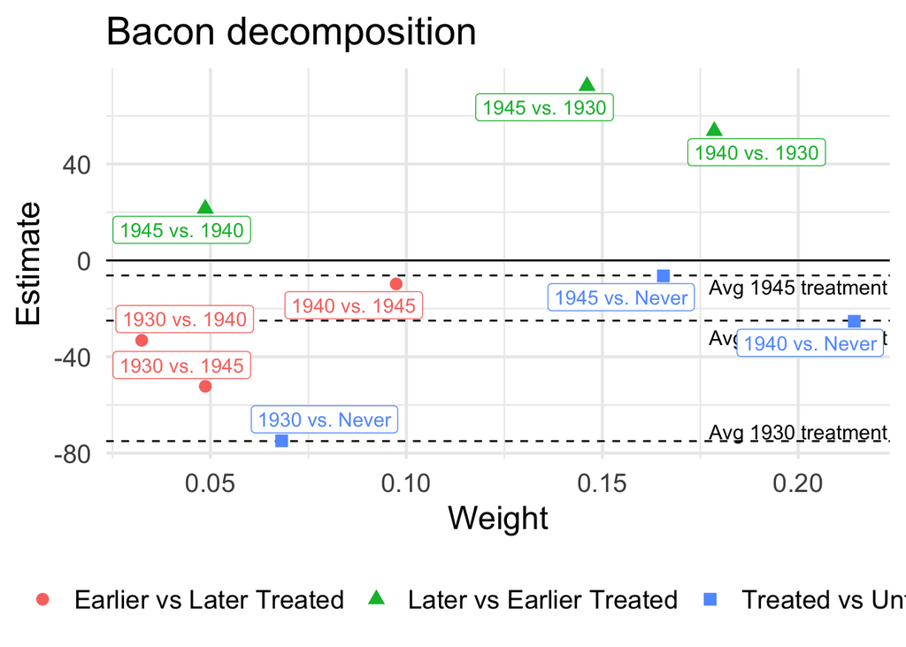

```r
timing_yes_growing_yes_bacon_plot = ggplot(timing_yes_growing_yes_bacon) +
      geom_hline(yintercept = att_1930, linetype = "dashed") +
    geom_hline(yintercept = att_1940, linetype = "dashed") +
    geom_hline(yintercept = att_1945, linetype = "dashed") +
  aes(x = weight, y = estimate, shape = factor(type), label = label, color = factor(type)) +
  geom_point(size = 3) +
  geom_hline(yintercept = 0) +
  theme_minimal(base_size = 18) +
        geom_point(x = .2, y = att_1940, alpha = 0, size = 3) +
    geom_point(x = .2, y = -30, size = 3, alpha = 0) +
    geom_point(x = .2, y = -25, size = 3, alpha = 0) +
    annotate("text", label = "Avg 1930 treatment", x = .2, y = att_1930*.95, size = 4)   +
    annotate("text", label = "Avg 1940 treatment", x = .2, y = -32, size = 4)    +
    annotate("text", label = "Avg 1945 treatment", x = .2, y = -11, size = 4)    +
          geom_label_repel(force = 10, max.time = 10, show.legend = FALSE, seed = 1234) +
  labs(x = "Weight", y = "Estimate", shape = "Type", color = "Type", title = "Bacon decomposition") +
     guides(col = guide_legend(ncol = 3)) +
    theme(legend.position="bottom",
          legend.title = element_blank())





timing_yes_growing_yes_bacon_plot
```

# Plot the five treatment effect comparisons next to one another.

```r
 # Create storage dataset.
  timing_yes_growing_yes_att_data = data.table(order = numeric(), b=numeric(), se=numeric(), Method=character())

  # Add TWFE results to storage dataset
    timing_yes_growing_yes_att_data = rbind(timing_yes_growing_yes_att_data, timing_yes_growing_yes_twfe_att,
                                           use.names = FALSE)

    # Add CS results to storage dataset
    timing_yes_growing_yes_att_data = rbind(timing_yes_growing_yes_att_data, timing_yes_growing_yes_cs_att,
                                           use.names = FALSE)

    # Add Unbalanced-Stacked results to storage dataset
    timing_yes_growing_yes_att_data = rbind(timing_yes_growing_yes_att_data, timing_yes_growing_yes_stacked_att,
                                           use.names = FALSE)

    # Add Balanced-Stacked -2:2 results to storage dataset
    timing_yes_growing_yes_att_data = rbind(timing_yes_growing_yes_att_data, stacked_balanced_k_2_att,
                                           use.names = FALSE)

    # Add Balanced-Stacked -2:4 results to storage dataset
    timing_yes_growing_yes_att_data = rbind(timing_yes_growing_yes_att_data, stacked_balanced_k_2_4_att,
                                           use.names = FALSE)

    # Ensure storage is numeric where it should be
    timing_yes_growing_yes_att_data[, b := as.numeric(b)]
    timing_yes_growing_yes_att_data[, se := as.numeric(se)]
    timing_yes_growing_yes_att_data[, order := as.numeric(order)]
```

Plot the ATTs next to one another.

```r
    # Add truth
    true_avg_att = annual_avg_treatment_effect[event_time >= 0, list(avg_true_treatment_effect = fmean(avg_true_treatment_effect))]

    true_avg_att_2 = unlist(annual_avg_treatment_effect[event_time >= 0 & event_time <= 2, list(avg_true_treatment_effect = fmean(avg_true_treatment_effect))])

    true_avg_att_4 = unlist(annual_avg_treatment_effect[event_time >= 0 & event_time <= 4, list(avg_true_treatment_effect = fmean(avg_true_treatment_effect))])

    true_avg_att = mean(true_avg_att$avg_true_treatment_effect)
```

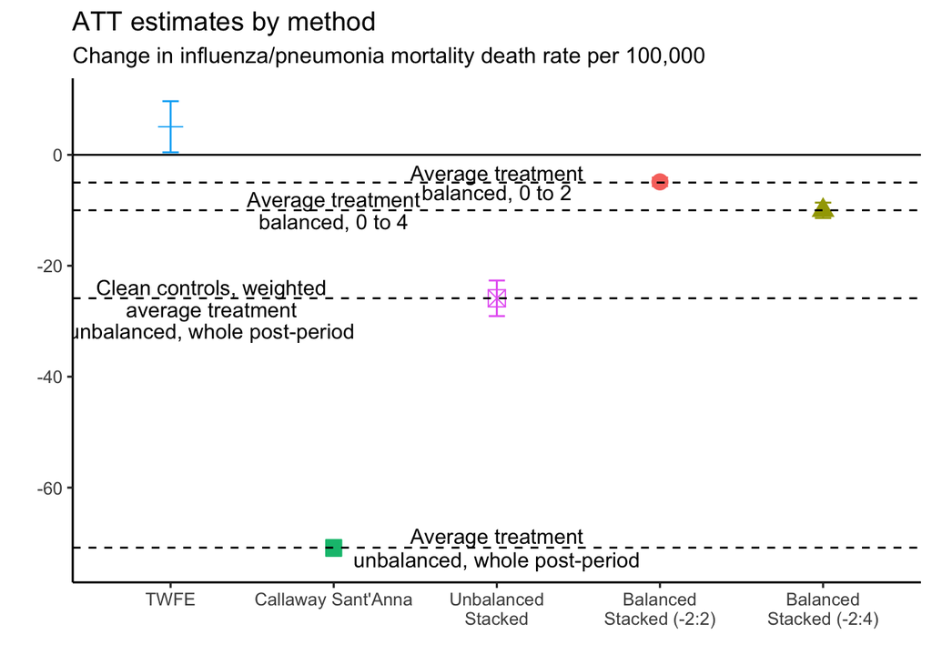

```r
timing_yes_growing_yes_att_plot = ggplot(data = timing_yes_growing_yes_att_data,
       aes(x = factor(order),
           y = b,
           ymin = b - 1.96*se,
           ymax = b + 1.96*se,
           shape = Method,
           color = Method)) +
    geom_point(size=4) +
    geom_errorbar(width=0.1) +
    theme_minimal() +
    geom_hline(yintercept = 0) +
    geom_hline(yintercept = true_avg_att_2, linetype = "dashed") +
    geom_hline(yintercept = true_avg_att_4, linetype = "dashed") +
    geom_hline(yintercept = true_avg_att, linetype = "dashed") +
    geom_hline(yintercept = bacon_stacked, linetype = "dashed") +
    annotate("text", label = "balanced, 0 to 4", x = 2, y = true_avg_att_4*1.2, size = 4)   +
    annotate("text", label = "Average treatment", x = 2, y = true_avg_att_4*.8, size = 4)   +

    annotate("text", label = "Average treatment", x = 3, y = true_avg_att_2*.65, size = 4)   +
    annotate("text", label = "balanced, 0 to 2", x = 3, y = true_avg_att_2*1.35, size = 4)   +

    annotate("text", label = "Average treatment", x = 3, y = true_avg_att*(1-.03), size = 4)   +
    annotate("text", label = "unbalanced, whole post-period", x = 3, y = true_avg_att*1.03, size = 4)   +

    annotate("text", label = "Clean controls, weighted", x = 1.25, y = bacon_stacked*.925, size = 4)   +
    annotate("text", label = "average treatment", x = 1.25, y = bacon_stacked*1.075, size = 4)   +
    annotate("text", label = "unbalanced, whole post-period", x = 1.25, y = bacon_stacked*1.225, size = 4)   +
    labs(title = "ATT estimates by method",
         y = "",
         subtitle = "Change in influenza/pneumonia mortality death rate per 100,000",
         x = "")  +
    scale_x_discrete(breaks=c("1","2","3", "4", "5"),
        labels=c("TWFE", "Callaway Sant'Anna", "Unbalanced\nStacked", "Balanced\nStacked (-2:2)", "Balanced\nStacked (-2:4)")) +
    theme_classic(base_size = 12) +
theme(legend.position = "none")
timing_yes_growing_yes_att_plot
```

# Event-study comparison

Plot the event-studies on top of one another.

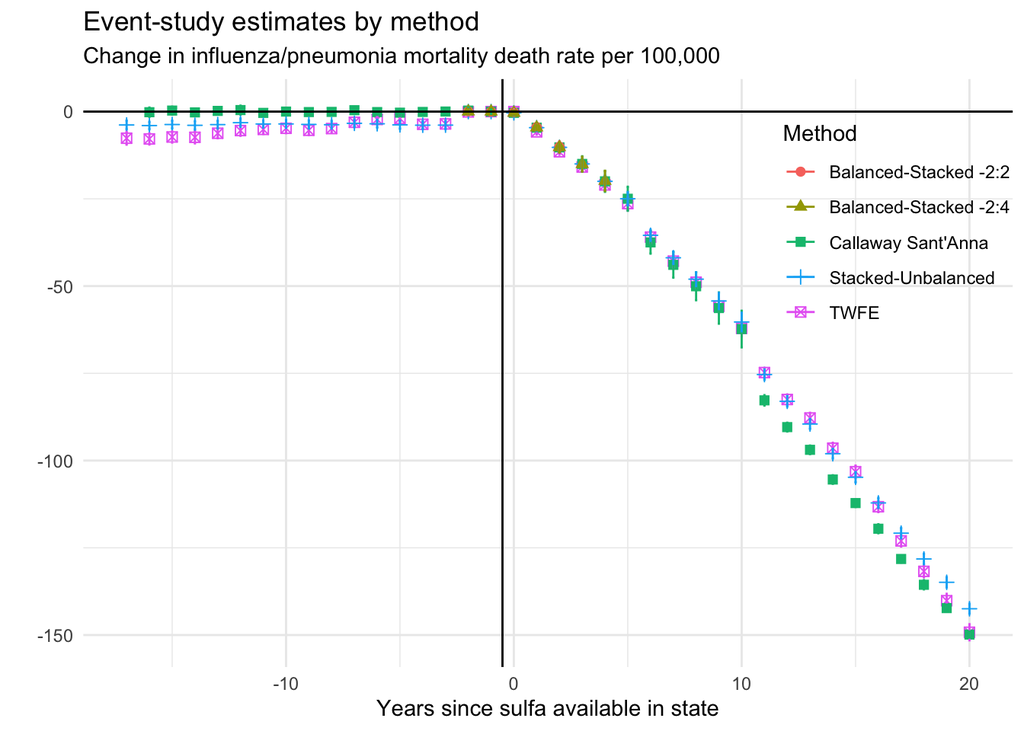

```r
timing_yes_growing_yes_es_plot = ggplot(data = timing_yes_growing_yes_es_data,
       aes(x = event_time,
           y = b,
           ymin = b - 1.96*se,
           ymax = b + 1.96*se,
           shape = Method,
           color = Method)) +
    geom_point(size=2) +
    geom_errorbar(width=0.1) +
    theme_minimal() +
    geom_vline(xintercept = -.5) +
    geom_hline(yintercept = 0) +
    labs(title = "Event-study estimates by method",
         y = "",
         subtitle = "Change in influenza/pneumonia mortality death rate per 100,000",
         x = "Years since sulfa available in state")  +
  theme(legend.position = c(.875, .75))
timing_yes_growing_yes_es_plot
```

Zoom into -8 to +8, where the majority of treated years are, to see how TWFE is different that other two methods.

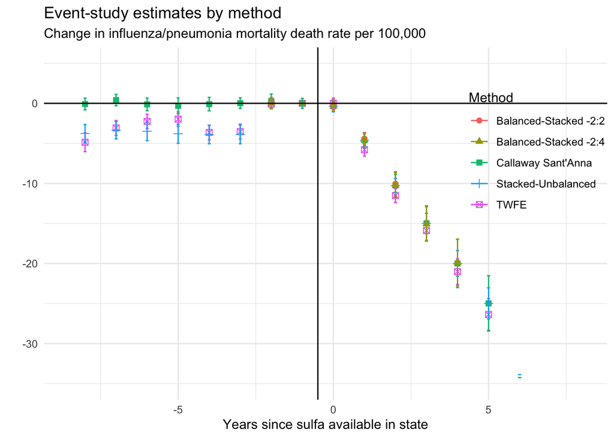

```r
timing_yes_growing_yes_es_zoom_plot = timing_yes_growing_yes_es_plot +
    xlim(-8.5, 8) +
    ylim(-35, 5)  +
  theme(legend.position = c(.875, .7))

timing_yes_growing_yes_es_zoom_plot
```

```r
ggsave(plot = timing_yes_growing_yes_es_zoom_plot,
       filename = "output/timing_yes_growing_yes_es_zoom_plot.pdf",
      height = 6,
      width = 9,
      units = "in")
```